Review

[figure not shown]

Translation from animal studies of novel

pharmacological therapies to clinical trials in cardiac

arrest: A systematic review

Peter Carøe Lind <sup>a</sup><sup>,</sup><sup>1</sup>, Cecilie Munch Johannsen <sup>a</sup><sup>,</sup><sup>1</sup>, Lauge Vammen <sup>a</sup><sup>,</sup><sup>b</sup>,

Andreas Magnussen <sup>a</sup>, Lars W. Andersen <sup>b</sup><sup>,</sup><sup>c</sup><sup>,</sup><sup>d</sup>, Asger Granfeldt <sup>a</sup><sup>,</sup><sup>b</sup><sup>,</sup><sup>e</sup><sup>,</sup>*

a Department of Clinical Medicine, Aarhus University, Aarhus, Denmark

b Department of Intensive Care and Anesthesiology, Aarhus University Hospital, Aarhus, Denmark

c Research Center for Emergency Medicine, Department of Clinical Medicine, Aarhus University and Aarhus University Hospital, Aarhus, Denmark

d Prehospital Emergency Medical Services, Central Denmark Region, Denmark

e Department of Anesthesiology and Intensive Care Medicine, Randers Regional Hospital, Randers, Denmark

Abstract

Background: There is a lack of new promising therapies to improve the dismal outcomes from cardiac arrest. The objectives of this study were: (1) To

identify novel pharmacological therapies investigated in experimental animal studies and (2) to identify pharmacological therapies translated from

experimental animal studies to clinical trials.

Methods: PubMed was searched to first identify relevant experimental cardiac arrest animal models published within the last 20 years. Based on this, a

list of interventions was created and a second search was performed to identify clinical trials testing one of these interventions. Data extraction was

performed using standardised data extraction forms.

Results: We identified 415 animal studies testing 190 different pharmacological interventions. The most commonly tested interventions were classified

as vasopressors, anaesthetics/gases, or interventions aimed at molecular targets. We found 43 clinical trials testing 26 different interventions identified

in the animal studies. Of these, 13 trials reported positive findings and 30 trials reported neutral findings with regards to the primary endpoint. No study

showed harm of the intervention. Some interventions tested in human clinical trials, had previously been tested in animal studies without a positive effect

on outcomes. A large number of animal studies was performed after publication of a clinical trial.

Conclusion: Numerous different pharmacological interventions have been tested in experimental animal models. Despite this only a limited number of

these interventions have advanced to clinical trials, however several of the clinical trials tested interventions that were first tested in experimental animal

models.

Keywords: Cardiac arrest, Animal models, Clinical trials, Interventions, Drugs, Review

Introduction

Currently the only drugs recommended as standard for use during

cardiac arrest are epinephrine and amiodarone/lidocaine.<sup>1</sup><sup>�</sup><sup>4</sup>The

number of clinical trials investigating interventions during cardiac

arrest are outnumbered by studies within other fields of cardiovascular

medicine such as ischemic heart disease, stroke and chronic heart

failure.<sup>5</sup>This compares unfavourably with the substantial morbidity

and mortality associated with cardiac arrest, with cardiac arrest as the

* Corresponding author at: Department of Intensive Care, Aarhus University hospital, Palle Juul Jensens Blvd. 99 G304, 8200 Aarhus N, Denmark.

E-mail address: granfeldt@gmail.com (A. Granfeldt).

1 Shared first authors.

https://doi.org/10.1016/j.resuscitation.2020.10.028

Received 30 July 2020; Received in revised form 9 October 2020; Accepted 15 October 2020

0300-9 © 2020 Elsevier B.V. All rights reserved.

[figure not shown]

third leading cause of disability-adjusted life years.<sup>6</sup>In a recent review

on drugs during cardiopulmonary resuscitation, only six ongoing

clinical trials were identified. Furthermore, out of 48 online registered

trials for post-cardiac arrest interventions only 14 included pharma-

cological agents and several of these are already available in clinical

practice.<sup>7,8</sup>This lack of new promising therapies to improve the dismal

outcomes from cardiac arrest illustrates a serious concern within the

field of cardiac arrest.

A systematic review on novel pharmacological therapies investi-

gated in experimental animal studies could inform researchers on new

promising

pharmacological

interventions

and

on

interventions

transferred from the animal laboratory to the clinical setting.

The aim of this systematic review was to identify novel

pharmacological therapies investigated in experimental animal

studies and to identify the number of therapies translated from

experimental animal studies to clinical trials.

Methods

Overview

The objective of this paper was twofold: (1) To identify novel

pharmacological therapies investigated in experimental animal studies

and (2) to identify pharmacological therapies translated from

experimental animal studies to human clinical trials. We first performed

a search to identify experimental cardiac arrest animal models. Based

on this, a list of interventions was created and a second search was

performed to identify clinical trials testing one of these interventions.

The review was not registered as it did not compare specific

interventional strategies and no detailed review protocol existed.

However, the eligibility criteria, search strategies, and a detailed data

extraction protocol were created prior to performing the search.

Eligibility criteria

Experimental cardiac arrest animal models

An experimental cardiac arrest animal model was defined as intentional

induction of cardiac arrest with subsequent cardiopulmonary resusci-

tation including manual/mechanical chest compressions or extracor-

poreal cardiopulmonary resuscitation.<sup>9</sup>Only in vivo studies performed

in mammals were included. Pharmacological interventions were

defined as a drug administered intra- or post-cardiac arrest to obtain

a specific effect. Combinations of pharmacological interventions were

also included. Fluids were not considered a pharmacological interven-

tion. The pharmacological intervention had to be compared to a control

group (no-treatment, placebo or standard treatment of adrenaline or

amiodarone/lidocaine). We excluded cardiac arrest animal models

where the cardiac arrest was induced by injection of a pharmacological

agent,such asa tricyclicanti-depressantorlocal anaesthetic(lidocaine,

bupivacaine, ropivacaine etc.). However, an exception to this exclusion

criterion was cardiac arrest asphyxia models where a muscle relaxant

was used, which were included in the review. It was a priori decided not

to include studies with adrenaline, lidocaine and amiodarone as

interventions, as these are recommended by guidelines and regarded

as standard therapy.<sup>10</sup>

Clinical trials

Aclinical interventionaltrialwas definedasarandomisedtrialassessing

the intervention of interest in adults with cardiac arrest in any setting (in-

hospital or out-of-hospital). Adults were defined as �18 years (or as

defined in individual studies). All types of randomised trials were

included.Thisincluded quasi-randomisedtrials(e.g.assignment based

on day of the week) as well as cluster-randomised trials.

Information source and search strategy

Experimental animal studies

To identify experimental animal studies, PubMed was searched from

24.02.2000 to 24.02.2020. We only searched PubMed as the gain

from including other databases was expected to be low based on our

experiences from previous systematic reviews of cardiac arrest

interventions.<sup>1,11,12</sup>The first part of the search contained keywords

relevant to cardiac arrest, while the second part included relevant

types of animals as previously described.<sup>9</sup>The full search strategy is

provided in the Supplemental material.

Clinical trials

To identify clinical trials testing the identified pharmacological

interventions, we searched PubMed on 11.06.2020. The first part

of the search contained keywords relevant to cardiac arrest as

previously used.<sup>12</sup>The second part identified randomised clinical

trials using the Cochrane sensitivity- and precision-maximising search

strategy for identification of randomised clinical trials.<sup>13</sup>The third part

contained the identified pharmacological interventions listed in the

Supplement material. The search was performed for each intervention

category separately. The full search strategy is provided in the

Supplemental material.

For both searches, using pre-defined screening criteria, pairs of

two reviewers, independently screened all titles and abstracts. The

reviewers were blinded to authors and journal titles during the

screening stage. Any disagreements regarding inclusion or exclusion

were resolved via discussion between the reviewers and with a third

reviewer as needed. The same reviewers then reviewed the full-text

articles of all potentially relevant publications passing the first level of

screening. Any disagreement regarding eligibility was resolved via

discussion until consensus was reached. The Kappa-value for inter-

observer variance was calculated.

Data collection

Reviewers, using a pre-defined standardised data extraction form,

extracted data from individual studies. For evaluation of outcomes in

the experimental animal studies we used the following definitions: a)

Clinically relevant outcomes included return of spontaneous circula-

tion, survival and survival with a favorable neurological outcome, b)

neurological outcomes included cerebral outcomes based on MRI,

CT, histology, blood markers, microdialysis, near-infrared spectros-

copy, electrophysiology etc., c) cardiovascular outcomes included

cardiac output, haemodynamics, blood markers, echocardiography,

MRI, cardiac histology, and d) other outcomes include respiratory

outcomes, renal outcomes, other blood markers etc.

Statistical analysis

Categorical variables are presented as counts (frequencies) and

continuous variables as mean with standard deviation (SD), while

non-normally distributed continuous values are presented as median

and interquartile range (IQR). Data analyses were performed with

Stata 14.0 (StataCorp LP, College Station, TX, USA).

Results

Study selection

Experimental animal studies

A total of 6107 unique records were identified. After review of

abstracts, 5658 records were excluded (Kappa = 0.79). Following full-

text review, 34 articles were excluded (kappa = 0.66). Reasons for

exclusion are listed in Fig. 1. Several of the included studies tested

more than one intervention, therefore, a total of 415 studies testing

439 interventions were included. These were published in 110 different

journals with an increasing number of studies published over time

(Fig. S1, Supplement material)

Clinical trials

Study characteristics

Experimental animal studies

The most commonly used animal species were rats and pigs with electric

pacing and asphyxia as the most common methods of inducing cardiac

arrest (Table 1). A total of 190 different interventions were identified with the

most commonly tested interventions classified as vasopressors, anaes-

thetics/gases, or interventions aimed at specific molecular targets

(Table S1, Supplement material). The average no-flow period was 8.0

(SD 4.6) minutes while the average time to from cardiac arrest to drug

administration was 9.0 (SD 4.9) minutes. For clinically relevant outcomes

42% reported no effect while 37% reported that the intervention improved

survival. The majority of studies did not report on neurological outcomes,

but for those who did, the majority reported an improvement (Table 1). Out

of 190 different interventions, 120 interventions were only tested once. In

contrast, 12 interventions were tested in more than five studies with

40 studies testing the effects of vasopressin. 15% of the survival studies

applied targeted temperature management with median duration of 4 h

(IQR 2�12). For details see the Supplemental material.

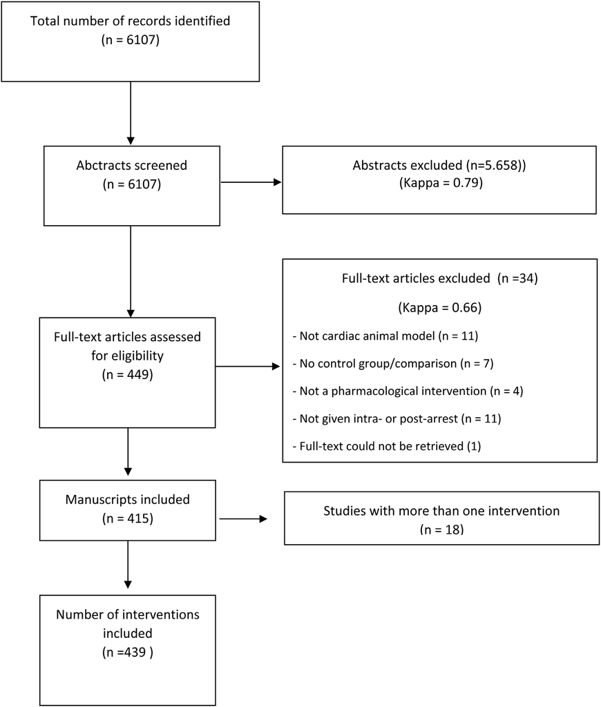

Fig. 1 – PRISMA diagram.

Diagram illustrating the flow of articles throughout the selection procedures of experimental animal studies.

Clinical trials

26 different interventions (Table 2/Table S2). When evaluating the

29 trials published after 2000, 18 different interventions were tested.

Out of the 43 published trials, 13 trials reported positive findings and

30 trials reported neutral findings with regards to the primary endpoint.

No trials reported worse outcomes with the intervention being tested.

The majority of trials included patients with out-of-hospital cardiac

(OHCA) (n = 33) while few studies included patients with in-hospital-

cardiac arrest (IHCA) (n = 5) or both OHCA and IHCA (n = 5). Out of the

30 most tested interventions in experimental animal studies, only 9

(30%) of the interventions had been tested or was in the process of

being tested in a human clinical trial (Table 3). Some interventions

tested in human clinical trials, had previously been tested in animal

studies without a positive effect on outcomes. A large number of

animal studies was performed after publication of a clinical trial.

Discussion

In the current study, we identified 415 experimental animal studies

testing 190 different pharmacological interventions published within the

last 20 years. The majority of the interventions were only tested once.

When searching for human clinical trials testing one of the 190 different

interventions, we identified 43 trials testing 26 different interventions.

Some of these intervention had previouslybeentested inanimal studies

without a positive effect on outcomes, while a large number of animal

studies was performed after publication of a clinical trial.

Survival from cardiac arrest has increased over the last decades,

which primarily has been attributed to an increase in bystander

interventions such as bystander CPR and use of automated external

defibrillators (AED).<sup>14</sup><sup>�</sup><sup>17</sup>

However, the increase in bystander

interventions and survival may have reached a plateau.<sup>16</sup><sup>�</sup><sup>18</sup>Although

strategies to increase survival will likely include additional strategies to

increase layperson involvement, new interventions and approaches

to patients with cardiac arrest are also needed to further improve

outcomes.<sup>19</sup>Over the years there have been few changes in the

recommended drugs during cardiopulmonary resuscitation. Adrena-

line has been included in resuscitation guidelines since the 1960s

while amiodarone was included in the 2000 guidelines with further

emphasis in the 2005 guidelines.<sup>20,21</sup>Currently there are limited data

and ongoing trials to support the inclusion of new intra-cardiac arrest

into the resuscitation guidelines, with only six ongoing clinical trials of

drugs during adult cardiopulmonary resuscitation.<sup>8</sup>In that context, it is

encouraging that 190 different interventions have been tested in

experimental animal models and that the number has been increasing

over the years, as experimental animal studies are the breeding

ground for potential discoveries and new interventions.

Cardiac

arrest

researchers

have

demonstrated

that

large

randomised trials can be performed with regards to both intra-arrest

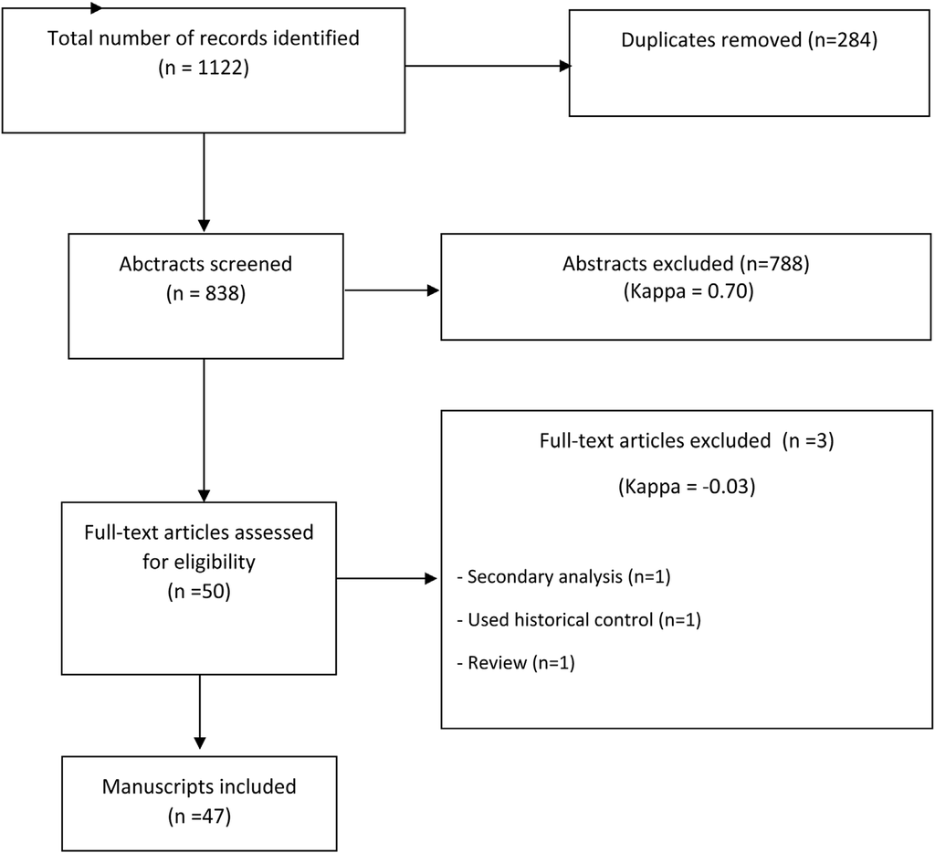

Fig. 2 – PRISMA diagram.

Diagram illustrating the flow of articles throughout the selection procedures of clinical studies.

and post-cardiac arrest intervention.<sup>2,3,22</sup>With regards to intra-cardiac

arrest pharmacological interventions, studies are often performed on

OHCA patients where the time to drug delivery is approximately

20 min after the onset of cardiac arrest. This is very different from

experimental studies where the average time from cardiac arrest to

drug administration is 9 min and where the protective effect is often lost

if treatment is delayed.<sup>9,23</sup>This lack of experimental animal studies to

recapitulate the severity and characteristics of human clinical cardiac

arrest illustrates a continuous concern.<sup>9,24</sup>This is also illustrated by

the low number of survival studies applying controlled temperature

management. In contrast, few studies have been performed on

patients with IHCA where the time to drug delivery is considerably

shorter.<sup>25,26</sup>The IHCA population may therefore be a more suitable

population for testing new promising interventions. Examples of

interventional trials in the IHCA population are the two trials testing

vasopressin, epinephrine, and corticosteroids for in-hospital cardiac

arrest.<sup>27,28</sup>Both studies reported promising improvements in survival

and survival with a good neurological outcome. Although the studies

were not directly based on experimental animal studies testing the

specific combination of vasopressin and corticosteroids, the idea of

adding vasopressin to adrenalin was based on an experimental

animal study.<sup>29</sup>

Examples of interventions that were successfully tested in first

experimental animal studies and brought into clinical trials includes

erythropoietin, Shen Fu, xenon, and nitrite.<sup>30</sup><sup>�</sup><sup>34</sup>These interventions

are characterised by a number of animal studies demonstrating an

improvement in outcomes preceding the clinical trials, although a

number of animal studies also reported no beneficial effect. The

clinical trials of erythropoietin and nitrite reported neutral results, while

Table 1 – Experimental animal study characteristics.

Number<sup>a</sup>(%)

Animal species

Mouse

28 (6)

Rat

203 (46)

Rabbit

15 (4)

Canine (dog)

12 (3)

Pig

181 (41)

Cardiac arrest model

Electric pacing

253 (57)

Asphyxia

118 (27)

Potassium

35 (8)

Myocardial infarction

5 (1)

Combination

20 (5)

Other<sup>b</sup>

6 (1)

Not reported<sup>c</sup>

2 (1)

Intervention category

Anesthetics/gases

56 (13)

Anti-arrhythmic agents

25 (6)

Anti-inflammatory

36 (8)

Anti-oxidants

9 (2)

Buffers

4 (1)

Coagulation

7 (1)

Combination therapy

24 (5)

Enzymes/proteases

3 (1)

Herbs/plants

23 (5)

Hormones

22 (5)

Metabolic

12 (3)

Mitochondria

19 (4)

Molecules/molecular targets

47 (11)

Nitrite /bitric oxide/ sodium nitroprusside

20 (4)

Peptides

13 (3)

Pharmacological hypothermia

16 (4)

Vasodilators/inodilators

20 (4)

Vasopressors

74 (17)

Vitamins

5 (1)

Other

4 (1)

Route of administration

Intravenous

324(74)

Intra-peritoneal

31 (7)

Intramuscular/subcutaneously/Intraosseous

7 (2)

Inhalation

37 (8)

Oral

4 (1)

Intraventricular brain injection

9 (2)

Other<sup>d</sup>

14 (3)

Not reported

13 (3)

Timing of invention

Intra-cardiac arrest

207 (47)

Post-cardiac arrest

192 (44)

Intra- and post-cardiac arrest

40 (9)

Acute study/survival study<sup>e</sup>

Acute study

186 (42)

Survival study

253(58)

Clinical relevant outcomes

Improve

162 (37)

Worse

8 (2)

No effect

184 (42)

Conflicting findings

4 (1)

Not reported

81 (18)

Neurological outcomes

Table 1 (continued)

Number<sup>a</sup>(%)

Improve

163 (37)

Worse

5 (1)

No effect

66 (15)

Conflicting findings

7 (2)

Not reported

198 (45)

Cardiovascular outcomes

Improve

142 (32)

Worse

13 (3)

No effect

151 (34)

Conflicting findings

11 (3)

Not reported

122 (28)

Other outcomes

Improve

65 (15)

Worse

1 (0)

No effect

27 (6)

Conflicting findings

0 (0)

Not reported

346 (80)

a The numbers are based on the total number of interventions, which

exceeds the number of studies.

b Pulmonary embolism, major vessel occlusion.

c Refers to previous publications.

d Includes aortic flush, intra-arterial, combinations.

e Acute study — animals are never awakened from anaesthesia, Survival —

animals are awakened from anaesthesia.

Table 2 – Clinical trials testing interventions of interest after year 2000.

First author, year

Intervention

category

Intervention

Number of

animal

studies total

Number of

animal

studies priora

Patient

population

Sample

size

Comparator

Primary outcome

Main result

Mader 200358

Other

Aminophylline

1

0

OHCA

111

Placebo

Return of sponta-

neous circulation

Neutral

Abu-Laban 200659

Other

Aminophylline

1

1

OHCA

971

Placebo

Return of sponta-

neous circulation

Neutral

Argaud 201630

Mitochrondria

Cyclosporine

7

0

OHCA

794

Standard care

Sequetial Organ

Failure Assess-

ment (SOFA) score

Neutral

Cariou 201660

Hormones

Erythropoietin

9

4

OHCA

476

Standard care

Cerebral perfor-

mance category

score 1 at 60 days

Neutral

Wiberg 201637

Hormones

Glucagon-like-pep-

tide-1

2

2

OHCA

120

Placebo

Feasibility and

Neuron Specific

Enolase Area un-

der the curva after

72 h

Neutral

Tamura 201761

Anesthetics/

gases

Hydrogen

8

6

OHCA

360

Placebo

Favorable 90-day

neurological

outcome

Protocolb

Bjelland 201238

Anesthetics/

gases

Midazolam and

fentanyl versus

propofol and

remifentanil

1

0

Both

60

Other drug

Time from discon-

tinuation of infu-

sions to extubation

or decision not to

extubate

Positive

Yoshioka 200662

Antiarrhythmic

agents

Nifekalant

2

0

Both

91

Other drug

Not defined

Positivec

Amino 201063

Antiarrhythmic

agents

Nifekalant

2

0

OHCA

30

Other drug

Not defined

Neutral

Zhang 201732

Herbs/plants

Shen Fu

15

3

IHCA

978

Standard care

28 day mortality

Positive

Shao 202031

Herbs/plants

Shen Fu

15

6

OHCA

1201

Placebo

survival to hospital

admission

Positive

Vukmir 200664

Buffers

Sodium

bicarbonate

1

0

OHCA

792

Placebo

Return of sponta-

neous circulation

and presenting to

the emergency de-

partment with a

pulse

Neutral

Ahn 201865

Buffers

Sodium

bicarbonate

1

1

OHCA

50

Placebo

Change in acidosis

Positive

Dezfulian 201833

Nitrite/Nitric ox-

ide/SNP

Sodium nitrite high

and low dose

4

1

OHCA

11

Placebo

Feasibilty and hy-

potension as an

adverse event

Neutral

(continued on next page)

Table 2 (continued)

First author, year

Intervention

category

Intervention

Number of

animal

studies total

Number of

animal

studies priora

Patient

population

Sample

size

Comparator

Primary outcome

Main result

Abu-Laban 200266

Coagulation

Tissue plasmino-

gen activator

1

0

Both

233

Placebo

Survival to hospital

discharge

Neutral

Fatovich 200467

Coagulation

Trombolysis/

Tenecteplase

1

0

OHCA

35

Placebo

Return of sponta-

neous circulation

Positive

Böttiger 200868

Coagulation

Trombolysis/

Tenecteplase

1

0

OHCA

1050

Placebo

30-day survival

Neutral

Liu 201769

Anti-

inflammatory

Ulinastatin + contin-

uous renal replace-

ment therapy

9

6

IHCA

70

Standard care

Multiple biomarkers

Positive

Stiell 200170

Vasopressors

Vasopressin

40

0

IHCA

200

Epinephrine

1 h survival

Neutral

Wenzel 200440

Vasopressors

Vasopressin

40

0

1186

Epinephrine

Survival to hospital

admission

Neutrald

Mukoyama 200971

Vasopressors

Vasopressin

40

11

OHCA

336

Epinephrine

Survival to hospital

discharge and fa-

vorable neurologi-

cal outcome with

hospital discharge

Neutral

Ong 201272

Vasopressors

Vasopressin

40

24

OHCA

727

Epinephrine

Survival to hospital

discharge

Neutral

Mentzelopoulos 200927

Combination

therapy

Vasopressin + cor-

ticosteroidse

1

0

IHCA

100

Placebo

Return of sponta-

neous circulation

and survival to

hospital discharge

Positive

Mentzelopoulos 201328

Combination

therapy

Vasopressin + cor-

ticosteroidse

1

0

IHCA

300

Placebo

Return of sponta-

neous circulation

and survival to

hospital discharge

with a favorable

neurological

outcome

Positive

Callaway 200673

Vasopressors

Vasopressin + epi-

nephrine

5

2

OHCA

325

Epinephrine

Return of sponta-

neous circulation

Neutral

Gueugniaud 200839

Vasopressors

Vasopressin + epi-

nephrine

5

2

OHCA

2894

Epinephrine

Survival to hospital

admission

Neutral

Ghafourian 201574

Vasopressors

Vasopressin + epi-

nephrine

5

5

OHCA

100

Epinephrine

S100b

Neutral

Ducros 201175

Combination

therapy

Vasopressin + epi-

nephrine or Vaso-

pressin + epineph-

rine + nitroglycerin

2

0

OHCA

44

Epinephrine

Diastolic blood

pressure during

CPR

Neutral

the clinical trials of Shen Fu and xenon demonstrated promising

results. For xenon, this has led to a larger clinical trial (Xenon by

Inhalation for Post Out of Hospital Cardiac Arrest Syndrome

[XePOHCAS]). In contrast, a clinical trial of Glucagon-like peptide-

1 demonstrating neutral results was preceded by experimental

animals studies with no effect on the investigated clinical relevant

outomes.<sup>35</sup><sup>�</sup><sup>37</sup>It is also important to consider that not all clinical trials

need to be preceded by experimental animal studies. The study by

Bjelland et al.<sup>38</sup>tested propofol and remifentanil versus midazolam

and fentanyl for sedation during therapeutic hypothermia after cardiac

arrest. As the trial included already clinically approved drugs and a

clinically relevant endpoint of time to extubation, preceding animal

studies are less relevant. Likewise, interventions demonstrating

protective properties in corresponding diseases such a myocardial

ischemia-reperfusion injury and stroke may be translated directly to

cardiac arrest patients. In contrast, the effects of some interventions

that large randomised trials in humans have shown no improvements

in outcomes with vasopressin, it is questionable whether additional

animal studies will be beneficial.<sup>39,40</sup>

It is difficult to pinpointwhat determines whether an intervention is

transferred from the animal laboratory to the clinical setting. For

instance, the intervention most commonly tested in animal studies,

besides vasopressin and Shen Fu, is sodium hydrogen exchange

inhibitors, with some studies, including large animal studies,

demonstrating protective properties.<sup>41,42</sup>Yet no clinical studies have

tested the effects of sodium hydrogen exchange inhibitors in patients

with cardiac arrest. Methylene blue is another example with four out of

five large animal studies demonstrating neuroprotective effects and

no clinical studies testing methylene blue in patients with cardiac

arrest.<sup>43</sup><sup>�</sup><sup>47</sup>In a highly competitive research environment, research

groups often specialise within a specific field such as experimental

animals studies, observational studies, or clinical trials as each area

requires a different set of skills. With the ongoing emergence of new

journals dedicated to experimental research, promising findings from

animal studies may lack reach and promising findings in experimental

animal studies may not generate the necessary attention for clinical

researchers. Furthermore, the “reproducibility crisis” within experi-

mental research has led to a scepticism towards basic science and

experimental animal studies, which may limit enthusiasm from clinical

researchers.<sup>48</sup>

To address this scepticism meticulous testing of new interventions

in multiple animal models and laboratories before clinical translation

could be an answer. Inspiration for this can be found within fields such

as epilepsy, myocardial infarction, traumatic brain injury and stroke.<sup>49</sup>

�52 This includes the development of programs or consortiums that

screens potential new drugs in different animal models displaying

different aspects of the disease of interest. It also include a

standardization of endpoints that recapitulate human clinical features

and minimize bias across sites.<sup>50,51</sup>

Two promising interventions identified during this review is

hydrogen and glibenclamide. Hydrogen, an effective antioxidant,

and glibenclamide, a sulfonylurea receptor 1-transient receptor

potential M4 inhibitor, demonstrated an improvement in clinically

relevant outcomes in all included studies. Furthermore, glibenclamide

is already used clinically for the treatment of type 2 diabetes, while

hydrogen has been tested in clinical trials.<sup>53,54</sup><sup>�</sup><sup>57</sup>However, they have

only been tested in small animal models why studies in large animal

models is needed. We hope this review and list of potential promising

Table 2 (continued)

First author, year

Intervention

category

Intervention

Number of

animal

studies total

Number of

animal

studies priora

Patient

population

Sample

size

Comparator

Primary outcome

Main result

Arola 201376

Anesthetics/

gases

Xenon

4

3

OHCA

33

No comparator

Feasibility and car-

diac safety

Neutral

Laitio 201634

Anesthetics/

gases

Xenon

4

3

OHCA

110

Standard care

Severity of ische-

mic whitematter

brain injury in MRI

Positive

a Number of animal studies prior to start of patient inclusion. Note that animals studies published prior to 24.02.2000 were not included.

b Only published as a trial protocol.

c Positive effect on defibrillation rate.

d Significant effect in patients with asystole.

e Animal study used terlipressin.

interventions will bring focus to this area and encourage cardiac arrest

researchers within different disciplines to collaborate.

Limitations

Dividing the different interventions into categories have some degree

of subjectivity as some interventions could fit into several categories.

Similarly, when assessing the effect of the intervention on outcomes

this was broadly categorised in order to provide some overview.

Although we tried to standardise the categorisation and generally

adapted the authors’ conclusions, any categorisation comes with

some degree of subjectivity. Although the searches and study

selection were performed systematically we cannot rule out that

potential animal studies or clinical trials were missed. The review did

not include studies with adrenaline, lidocaine and amiodarone as

interventions. Hence, it is a limitation that the review did not include

studies testing the optimal dosing regimens ((e.g. dosing, time

between dosing, infusion)) of these drugs. Furthermore, the timespan

from initiation of a clinical trial to publication is often several years, why

we cannot rule out that ongoing trials were missed. However,

published trial protocols were included. In addition, as we excluded

trials where the intervention was administered prior to the cardiac

Table 3 – The experimental pharmacological interventions with most studies published.

Intervention

Intervention

category

Number of

animal

studies

total

Improvement in

Clinical relevant

outcomes

in<sup>Improvement</sup>

Neurological

outcomes

Improvement in

Cardiovascular

outcomes

Improvement

in Other

outcomes

Number of

clinical

studies

total

Vasopressin

Vasopressors

40

20/36 (56 %)

3/7 (43 %)

17/32 (53 %)

4/5 (80 %)

4

Shen Fu

Herbs/plants

15

1/10 (10 %)

2/5 (40 %)

10/13 (77 %)

7/7 (100 %)

2

Sodium hydrogen exchange

inhibitors

Molecules/molecu-

lar targets

14

2/12 (17 %)

1/4 (25 %)

6/12 (50 %)

2/4 (50 %)

0

Beta-blockers

Antiarrhythmic

agents

11

4/10 (40 %)

1/1 (100 %)

6/11 (55 %)

2/2 (100 %)

0

Erythropoietin

Hormones

9

4/8 (50 %)

2/2 (100 %)

2/8 (25 %)

3/4 (75 %)

1

Ulinastatin trypsin inhibitor

Anti-inflammatory

9

5/6 (83 %)

3/5 (60 %)

4/4 (100 %)

2

Hydrogen

Anesthetics/gases

8

8/8 (100 %)

7/8 (88 %)

3/6 (50 %)

1/3 (33 %)

0

Sevoflurane

Anesthetics/gases

8

1/7 (14 %)

1/2 (50 %)

3/7 (43 %)

2/4 (50 %)

0

Sodium nitroprusside

Nitrite/Nitric oxide/

Sodium

nitroprusside

7

6/7 (86 %)

2/3 (67 %)

5/7 (71 %)

1/1 (100 %)

0

Levosimendan

Vasodilators/

Inodilators

7

3/6 (50 %)

3/3 (100 %)

5/7 (71 %)

2/2 (100 %)

0

Cyclosporine

Mitochrondria

7

3/6 (50 %)

3/4 (75 %)

4/6 (67 %)

1

Argon

Anesthetics/gases

6

1/4 (25 %)

4/6 (67 %)

0/4 (0%)

0/2 (0%)

0

Glibenclamide

Metabolic

5

4/4 (100 %)

5/5 (100 %)

0/2 (0%)

0

Carbon monoxide

Anesthetics/gases

5

2/2 (100 %)

2/2 (100 %)

2/2 (100 %)

1/1 (100 %)

0

Hydrogen sulfide

Anesthetics/gases

5

4/5 (80 %)

5/5 (100 %)

1/1 (100 %)

1<sup>a</sup>

Isoflurane

Anesthetics/gases

5

2/5 (40 %)

3/4 (75)

0/5 (0%)

0

Sodium sulfide

Anesthetics/gases

5

2/5 (40 %)

3/5 (60 %)

1/4 (25 %)

0

Minocycline (tetracycline)

Anti-inflammatory

5

0/3 (0%)

3/5 (60 %)

0/2 (0%)

0

Estradiol

Hormones

5

1/4 (25 %)

1/3 (33 %)

0/2 (0%)

1/1 (100 %)

0

Nitric oxide

Nitrite/Nitric oxide/

Sodium

nitroprusside

5

4/5 (80 %)

3/4 (75 %)

2/4 (50 %)

1/2 (50 %)

0

Endothelin-1

Vasopressors

5

0/3 (0%)

0/1 (0%)

1/5 (20 %)

0

Methylene blue

Vasopressors

5

0/3 (0%)

4/4 (100 %)

0/3 (0%)

1/2 (50 %)

0

Naloxone

Vasopressors

5

2/5 (40 %)

0/1 (0%)

0/5 (0%)

0

Dobutamine

Vasodilators/

Inodilators

5

1/1 (100 %)

5/5 (100 %)

0/1 (0%)

Vasopressin + adrenaline

Vasopressors

5

1/5 (20 %)

1/2 (50 %)

1/4 (25 %)

1/2 (50 %)

3

Xenon

Anesthetics/gases

4

2/4 (50 %)

2/3 (66.7 %)

0/4 (0%)

2

Anti-tumor necrosis factor-a

Etanercept or Infliximab

Anti-inflammatory

4

1/2 (50 %)

3/4 (75 %)

0

Pyruvate

Metabolic

4

0/2 (0%)

2/2 (100 %)

0/3 (0%)

0

Nitrite

Nitrite/Nitric oxide/

Sodium

nitroprusside

4

1/4 (25 %)

2/3 (67 %)

2/4 (50 %)

1

Cannabinoid receptor agonist

WIN55, 212�2

Pharmacological

hypothermia

4

2/3 (67 %)

1/2 (50 %)

3/4 (75 %)

0

Alpha-methylnoradrenaline/

a-methylnorepinephrine/alfa-

2 adrenoceptor agonist

Vasopressors

4

2/3 (67 %)

2/4 (50 %)

0

Percentage of studies with an improvement in reported outcomes. If no outcomes reported field is left blank.

a Only published as a trial protocol.

arrest, clinical trials could have been based on an animal study were

the intervention was administered pre-cardiac arrest. The Kappa

value for full-text review of clinical studies was low and indicating an

agreement that is no better than that which would be obtained by

chance alone. This is partly due to the low number of articles, as there

was only disagreement with regards to the three excluded studies.

Conclusion

Numerous different pharmacological interventions have been tested

in experimental animal models. Despite this only a limited number of

these interventions have advanced to clinical trials, however several

of the clinical trials tested interventions that were first tested in

experimental animal models.

Author contribution

Allauthorshavecontributed toall theoffollowing: (1)theconceptionand

design of the study, or acquisition of data, or analysis and interpretation

of data, (2) drafting the article or revising it critically for important

intellectual content, (3) final approval of the version to be submitted.

Funding

None.

Conflict of interest

None.

CRediT authorship contribution statement

Peter Carøe Lind: Data curation, Investigation, Writing - review &

editing. Cecilie Munch Johannsen: Data curation, Investigation,

Writing - review & editing. Lauge Vammen: Data curation,

Investigation, Writing - review & editing. Andreas Magnussen: Data

curation, Investigation, Writing - review & editing. Lars W. Andersen:

Conceptualization, Investigation, Methodology, Supervision, Writing -

review & editing. Asger Granfeldt: Conceptualization, Data curation,

Formal analysis, Investigation, Methodology, Project administration,

Supervision, Writing - original draft, Writing - review & editing.

Appendix A. Supplementary data

Supplementary material related to this article can be found, in the

online version, https://doi.org/10.1016/j.resuscitation.2020.10.028.

R E F E R E N C E S

1. Holmberg MJ, Issa MS, Moskowitz A, et al. Vasopressors during adult

cardiac arrest: a systematic review and meta-analysis. Resuscitation

2019;139:106�21.

2. Perkins GD, Ji C, Deakin CD, et al. A randomized trial of epinephrine in

out-of-hospital cardiac arrest. New Engl J Med 2018;379:711�21.

3. Kudenchuk PJ, Brown SP, Daya M, et al. Amiodarone, lidocaine, or

placebo in out-of-hospital cardiac arrest. New Engl J Med

2016;374:1711�22.

4. Ali MU, Fitzpatrick-Lewis D, Kenny M, et al. Effectiveness of

antiarrhythmic drugs for shockable cardiac arrest: a systematic review.

Resuscitation 2018;132:63�72.

5. Ornato JP, Becker LB, Weisfeldt ML, Wright BA. Cardiac arrest and

resuscitation: an opportunity to align research prioritization and public

health need. Circulation 2010;122:1876�9.

6. Coute RA, Nathanson BH, Panchal AR, et al. Disability-adjusted life

years following adult out-of-hospital cardiac arrest in the United States.

Circ Cardiovasc Qual Outcomes 2019;12:e004677.

7. Andersen LW, Lind PC, Vammen L, Høybye M, Holmberg MJ,

Granfeldt A. Adult post-cardiac arrest interventions: an overview of

randomized clinical trials. Resuscitation 2019;147:1�11.

8. Vallentin MFGA, Holmberg MJ, Andersen LW. Drugs during

cardiopulmonary resuscitation. Curr Opin Crit Care 2020;26:242�50.

9. Vognsen M, Fabian-Jessing BK, Secher N, et al. Contemporary animal

models of cardiac arrest: a systematic review. Resuscitation

2017;113:115�23.

10. Nolan JP, Deakin CD, Soar J, Bottiger BW, Smith G. European

Resuscitation Council guidelines for resuscitation 2005. Section 4.

Adult advanced life support. Resuscitation 2005;67:S39�86.

11. Granfeldt A, Avis SR, Nicholson TC, Holmberg MJ, Moskowitz A,

Coker A, et al. Advanced airway management during adult cardiac

arrest: a systematic review. Resuscitation 2019;139:133�43.

12. Granfeldt A, Avis SR, Lind PC, et al. Intravenous vs. intraosseous

administration of drugs during cardiac arrest: a systematic review.

Resuscitation 2020;149:150�7.

13. Lefebvre CME, Glanville J. Searching for studies Chapter 6. In: Higgins

J, Green S, editors. Cochrane handbook for systematic reviews of

interventions. Version 5.1.0 (updated March 2011). The Cochrane

Collaboration; 2011 (Accessed 1 June 2020, at www.cochrane-

handbook.org).

14. Chan PS, McNally B, Tang F, Kellermann A. Recent trends in survival

from out-of-hospital cardiac arrest in the United States. Circulation

2014;130:1876�82.

15. Wissenberg M, Lippert Fk, Folke F, et al. Association of national

initiatives to improve cardiac arrest management with rates of

bystander intervention and patient survival after out-of-hospital

cardiac arrest. JAMA 2013;310:1377�84.

16. Fordyce CB, Hansen CM, Kragholm K, et al. Association of public

health initiatives with outcomes for out-of-hospital cardiac arrest at

home and in public locations. JAMA Cardiol 2017;2:1226�35.

17. Buick JE, Drennan IR, Scales DC, et al. Improving temporal trends in

survival and neurological outcomes after out-of-hospital cardiac

arrest. Circ Cardiovasc Qual Outcomes 2018;11:e003561.

18. Granfeldt A, Holmberg MJ, Donnino MW, Andersen LW, Group CS.

2015 guidelines for cardiopulmonary resuscitation and survival after

adult and pediatric out-of-hospital cardiac arrest. Eur Heart J Qual

Care Clin Outcomes 2020;31:qcaa027, doi:http://dx.doi.org/10.1093/

ehjqcco/qcaa027.

19. Bottiger BW, Becker LB, Kern KB, et al. BIG FIVE strategies for

survival following out-of-hospital cardiac arrest. Eur J Anaesthesiol

2020;37:955�8.

20. de Latorre F, Nolan J, Robertson C, Chamberlain D, Baskett P.

European Resuscitation Council Guidelines 2000 for Adult Advanced

Life Support: a statement from the Advanced Life Support Working

Group and approved by the Executive Committee of the European

Resuscitation Council. Resuscitation 2001;48:211�21.

21. Gough CJR, Nolan JP. The role of adrenaline in cardiopulmonary

resuscitation. Crit Care 2018;22:139.

22. Nielsen N, Wetterslev J, Cronberg T, et al. Targeted temperature

management at 33 <sup>�</sup>C versus 36 <sup>�</sup>C after cardiac arrest. New Engl J

Med 2013;369:2197�206.

23. Huang CH, Tsai MS, Hsu CY, et al. Post-cardiac arrest myocardial

dysfunction is improved with cyclosporine treatment at onset of

resuscitation but not in the reperfusion phase. Resuscitation 2011;82:

S41�7.

24. Fabian-Jessing BK, Vallentin MF, Secher N, et al. Animal models of

cardiac arrest: a systematic review of bias and reporting. Resuscitation

2018;125:16�21.

25. Andersen LW, Holmberg MJ, Berg KM, Donnino MW, Granfeldt A. In-

hospital cardiac arrest: a review. JAMA 2019;321:1200�10.

26. Sinha SS, Sukul D, Lazarus JJ, et al. Identifying important gaps in

randomized controlled trials of adult cardiac arrest treatments: a

systematic review of the published literature. Circ Cardiovasc Qual

Outcomes 2016;9:749�56.

27. Mentzelopoulos SD, Zakynthinos SG, Tzoufi M, et al. Vasopressin,

epinephrine, and corticosteroids for in-hospital cardiac arrest. Arch

Intern Med 2009;169:15�24.

28. Mentzelopoulos SD, Malachias S, Chamos C, et al. Vasopressin,

steroids, and epinephrine and neurologically favorable survival after

in-hospital cardiac arrest: a randomized clinical trial. JAMA

2013;310:270�9.

29. Stadlbauer KH, Wagner-Berger HG, Wenzel V, et al. Survival with full

neurologic recovery after prolonged cardiopulmonary resuscitation

with a combination of vasopressin and epinephrine in pigs. Anesth

Analg 2003;96:1743�9.

30. Argaud L, Cour M, Dubien PY, et al. Effect of cyclosporine in

nonshockable out-of-hospital cardiac arrest: the cyrus randomized

clinical trial. JAMA Cardiol 2016;1:557�65.

31. Shao F, Li H, Li D, Li C. Effects of Shenfu injection on survival and

neurological outcome after out-of-hospital cardiac arrest: a

randomised controlled trial. Resuscitation 2020;150:139�44.

32. Zhang Q, Li C, Shao F, Zhao L, Wang M, Fang Y. Efficacy and safety of

combination therapy of Shenfu injection and postresuscitation bundle

in patients with return of spontaneous circulation after in-hospital

cardiac arrest: a randomized, assessor-blinded, controlled trial. Crit

Care Med 2017;45:1587�95.

33. Dezfulian C, Olsufka M, Fly D, et al. Hemodynamic effects of IV sodium

nitrite in hospitalized comatose survivors of out of hospital cardiac

arrest. Resuscitation 2018;122:106�12.

34. Laitio R, Hynninen M, Arola O, et al. Effect of inhaled xenon on cerebral

white matter damage in comatose survivors of out-of-hospital cardiac

arrest: a randomized clinical trial. JAMA 2016;315:1120�8.

35. Dokken BBH, W. R, Teachey MK, et al. Glucagon-like peptide-1 (GLP-

1) attenuates post-resuscitation myocardial microcirculatory

dysfunction. Resuscitation 2010;81:755�60.

36. Dokken BBP, C. V, Teachey MK, et al. Glucagon-like peptide-

1 preserves coronary microvascular endothelial function after cardiac

arrest and resuscitation: potential antioxidant effects. Am J Physiol

Heart Circ Physiol 2013;304:H538�46.

37. Wiberg S, Hassager C, Schmidt H, et al. Neuroprotective effects of the

glucagon-like peptide-1 analog exenatide after out-of-hospital cardiac

arrest: a randomized controlled trial. Circulation 2016;134:2115�24.

38. Bjelland TW, Dale O, Kaisen K, et al. Propofol and remifentanil versus

midazolam and fentanyl for sedation during therapeutic hypothermia

after cardiac arrest: a randomised trial. Intensive Care Med

2012;38:959�67.

39. Gueugniaud PY, David JS, Chanzy E, et al. Vasopressin and

epinephrine vs. epinephrine alone in cardiopulmonary resuscitation. N

Engl J Med 2008;359:21�30.

40. Wenzel V, Krismer AC, Arntz HR, et al. A comparison of vasopressin

and epinephrine for out-of-hospital cardiopulmonary resuscitation. N

Engl J Med 2004;350:105�13.

41. Ayoub IM, Kolarova J, Yi Z, et al. Sodium-hydrogen exchange

inhibition during ventricular fibrillation: Beneficial effects on ischemic

contracture, action potential duration, reperfusion arrhythmias,

myocardial function, and resuscitability. Circulation 2003;107:

1804�9.

42. Kolarova JD, Ayoub IM, Gazmuri RJ. Cariporide enables

hemodynamically more effective chest compression by leftward shift

of its flow-depth relationship. Am J Physiol Heart Circ Physiol

2005;288:H2904�11.

43. Miclescu A, Sharma HS, Martijn C, Wiklund L. Methylene blue protects

the cortical blood-brain barrier against ischemia/reperfusion-induced

disruptions. Crit Care Med 2010;38:2199�206.

44. Martijn C, Wiklund L. Effect of methylene blue on the genomic

response to reperfusion injury induced by cardiac arrest and

cardiopulmonary resuscitation in porcine brain. BMC Med Genomics

2010;3:27.

45. Wiklund L, Patnaik R, Sharma A, Miclescu A, Sharma HS. Cerebral

tissue oxidative ischemia-reperfusion injury in connection with

experimental cardiac arrest and cardiopulmonary resuscitation: effect

of mild hypothermia and methylene blue. Mol Neurobiol 2018;55:

115�21.

46. Miclescu A, Basu S, Wiklund L. Methylene blue added to a hypertonic-

hyperoncotic solution increases short-term survival in experimental

cardiac arrest. Crit Care Med 2006;34:2806�13.

47. Wiklund L, Zoerner F, Semenas E, Miclescu A, Basu S, Sharma HS.

Improved neuroprotective effect of methylene blue with hypothermia

after porcine cardiac arrest. Acta Anaesthesiol Scand 2013;57:

1073�82.

48. Baker M. 1,500 scientists lift the lid on reproducibility. Nature

2016;533:452�4.

49. Wilcox KS, West PJ, Metcalf CS. The current approach of the Epilepsy

Therapy Screening Program contract site for identifying improved

therapies for the treatment of pharmacoresistant seizures in epilepsy.

Neuropharmacology 2020;166:107811.

50. Kochanek PM, Bramlett HM, Dixon CE, et al. Approach to modeling,

therapy evaluation, drug selection, and biomarker assessments for a

multicenter pre-clinical drug screening consortium for acute therapies

in severe traumatic brain injury: operation brain trauma therapy. J

Neurotrauma 2016;33:513�22.

51. Bosetti F, Koenig JI, Ayata C, et al. Translational stroke research:

vision and opportunities. Stroke 2017;48:2632�7.

52. Jones SP, Tang XL, Guo Y, et al. The NHLBI-sponsored Consortium

for preclinicAl assESsment of cARdioprotective therapies (CAESAR):

a new paradigm for rigorous, accurate, and reproducible evaluation of

putative infarct-sparing interventions in mice, rabbits, and pigs. Circ

Res 2015;116:572�86.

53. Ohta S. Recent progress toward hydrogen medicine: potential of

molecular hydrogen for preventive and therapeutic applications. Curr

Pharm Des 2011;17:2241�52.

54. Huang K, Wang Z, Gu Y, et al. Glibenclamide prevents water diffusion

abnormality in the brain after cardiac arrest in rats. Neurocrit Care

2018;29:128�35.

55. Nakayama S, Taguchi N, Isaka Y, Nakamura T, Tanaka M.

Glibenclamide and therapeutic hypothermia have comparable effect

on attenuating global cerebral edema following experimental cardiac

arrest. Neurocrit Care 2018;29:119�27.

56. Huang G, Zhou J, Zhan W, et al. The neuroprotective effects of

intraperitoneal injection of hydrogen in rabbits with cardiac arrest.

Resuscitation 2013;84:690�5.

57. Huo TT, Zeng Y, Liu XN, et al. Hydrogen-rich saline improves survival

and neurological outcome after cardiac arrest and cardiopulmonary

resuscitation in rats. Anesth Analg 2014;119:368�80.

58. Mader TJ, Smithline HA, Durkin L, Scriver G. A randomized controlled

trial of intravenous aminophylline for atropine-resistant out-of-hospital

asystolic cardiac arrest. Acad Emerg Med 2003;10:192�7.

59. Abu-Laban RB, McIntyre CM, Christenson JM, et al. Aminophylline in

bradyasystolic cardiac arrest: a randomised placebo-controlled trial.

Lancet 2006;367:1577�84.

60. Cariou A, Deye N, Vivien B, et al. Early high-dose erythropoietin

therapy after out-of-hospital cardiac arrest: a multicenter, randomized

controlled trial. J Am Coll Cardiol 2016;68:40�9.

61. Tamura T, Hayashida K, Sano M, Onuki S, Suzuki M. Efficacy of

inhaled HYdrogen on neurological outcome following BRain Ischemia

During post-cardiac arrest care (HYBRID II trial): study protocol for a

randomized controlled trial. Trials 2017;18:488.

62. Yoshioka K, Amino M, Morita S, et al. Can nifekalant hydrochloride be

used as a first-line drug for cardiopulmonary arrest (CPA)?

Comparative study of out-of-hospital CPA with acidosis and in-hospital

CPA without acidosis. Circ J 2006;70:21�7.

63. Amino M, Yoshioka K, Opthof T, et al. Comparative study of nifekalant

versus amiodarone for shock-resistant ventricular fibrillation in out-of-

hospital cardiopulmonary arrest patients. J Cardiovasc Pharmacol

2010;55:391�8.

64. Vukmir RB, Katz L, Sodium Bicarbonate Study G. Sodium bicarbonate

improves outcome in prolonged prehospital cardiac arrest. Am J

Emerg Med 2006;24:156�61.

65. Ahn S, Kim YJ, Sohn CH, et al. Sodium bicarbonate on severe

metabolic acidosis during prolonged cardiopulmonary resuscitation: a

double-blind, randomized, placebo-controlled pilot study. J Thorac Dis

2018;10:2295�302.

66. Abu-Laban RB, Christenson JM, Innes GD, et al. Tissue plasminogen

activator in cardiac arrest with pulseless electrical activity. N Engl J

Med 2002;346:1522�8.

67. Fatovich DM, Dobb GJ, Clugston RA. A pilot randomised trial of

thrombolysis in cardiac arrest (The TICA trial). Resuscitation

2004;61:309�13.

68. Böttiger BW, Arntz HR, Chamberlain DA, et al. Thrombolysis during

resuscitation for out-of-hospital cardiac arrest. N Engl J Med

2008;359:2651�62.

69. Liu Q, Peng J, Zhou Y, et al. Clinical observation of ulinastatin

combined with CRRT in the treatment of early cardiopulmonary

resuscitation. Exp Ther Med 2017;14:6064�8.

70. Stiell IG, Hebert PC, Wells GA, et al. Vasopressin versus epinephrine

for inhospital cardiac arrest: a randomised controlled trial. Lancet

2001;358:105�9.

71. Mukoyama T, Kinoshita K, Nagao K, Tanjoh K. Reduced

effectiveness of vasopressin in repeated doses for patients

undergoing prolonged cardiopulmonary resuscitation. Resuscitation

2009;80:755�61.

72. Ong ME, Tiah L, Leong BS, et al. A randomised, double-blind, multi-

centre trial comparing vasopressin and adrenaline in patients with

cardiac arrest presenting to or in the Emergency Department.

Resuscitation 2012;83:953�60.

73. Callaway CW, Hostler D, Doshi AA, et al. Usefulness of vasopressin

administered with epinephrine during out-of-hospital cardiac arrest.

Am J Cardiol 2006;98:1316�21.

74. Ghafourian N, Maniae NH, Taherikalani M, et al. Combination of

vasopressin-epinephrine as a novel candidate in patients with

cardiac arrest. Recent Adv Cardiovasc Drug Discov 2015;10:

65�9.

75. Ducros L, Vicaut E, Soleil C, et al. Effect of the addition of vasopressin

or vasopressin plus nitroglycerin to epinephrine on arterial blood

pressure during cardiopulmonary resuscitation in humans. J Emerg

Med 2011;41:453�9.

76. Arola OJ, Laitio RM, Roine RO, et al. Feasibility and cardiac safety of

inhaled xenon in combination with therapeutic hypothermia following

out-of-hospital cardiac arrest. Crit Care Med 2013;41:2116�24.